# BIOST 561: welcome + introduction of RStudio and GitHub

Lecture 1

# Welcome!

BIOST 561 treats advanced programming and computing skills for biostatistics.

We introduce a sophisticated use of `R`, as well as other programming techniques and tools, including an introduction to using UW Biostatistics’ computing resources.

# About the course…

I know from your previous courses that everyone is quite comfortable with `R` already! The purpose of this course is to

- get faster and more proficient at things you already know how to do
- go a bit deeper into the details of `R`
- learn how to write code that other people will run
- scale up!

# How to address me

“Kevin” is great. If that feels weird for you, “Professor Lin” is also great.

# Agenda for today?

- The “real” goals of the course
- Discussion of what problems an R package or GitHub are trying to solve
- Going over the syllabus
- Showcasing a demo GitHub repositories – simple example of what you will make for your final project
- Teaching the basics of git and GitHub

# Discussion: “Software engineer”

# Discussion: “Software engineer” = “Someone who codes”

- (In class: Pause for discussion)

# So… what’s *really* the goal of the course?

There is a ocean’s worth of difference between: 1) knowing how to write code, and 2) having the vision and execution to bring an entire vision’s into a stable code-base that other people can easily use.

You wouldn’t call:

- Anyone who can play the notes of Rachmaninoff No. 2, a master pianist
- Anyone who can sing Taylor Swift’s “Anti-Hero”, a star performer
- Anyone who can memorize Ryan Goslings’s lines in La La Land, a Oscar-winning actor

# Specific topics (Part 1)

- Separating product from process and gaining familiarity with RStudio and R projects
- Using Git and GitHub for version control and code distribution and integrating these tools into your typical coding workflow
- Writing R packages, including writing unit tests to ensure your code is properly maintained
- `tidyverse`, including `dplyr`, `magrittr` (i.e., pipes `%>%`), `tibble`, and `ggplot`
- Comfort in writing functions

# Specific topics (Part 2)

- Debugging, profiling code for speed and memory
- Writing simulation studies
- Basic familiarity with using the terminal
- Submitting code to be run on the server (specifically, the Bayes Biostatistics server)
- Creating a Pkgdown website and a personal website via Github.io

# Give me the vision

- A huge portion of the course is specifically about building familiarity with R packages and GitHub
- Why?
  - GitHub allows for efficient deployment of code so others can use it
  - There are tons of great software engineering tools in RStudio that are relevant for only R packages

# R packages: How to distribute your ideas

- You can install anyone’s R package via `install.packages()` or `devtools::install_github()`
- Nowadays, it’s often the case that what drives a paper’s success after publication:
  - **is not**: the intellectual nuances, the journals, the scientific novelty, the benchmarking
  - **is**: whether an bystander can easily install and run your code to help advance the science they’re interested in

# R packages: How to distribute your ideas

- Most biostatistics-related methods have humble coding beginnings
- See: https://bioconductor.org/packages/stats/

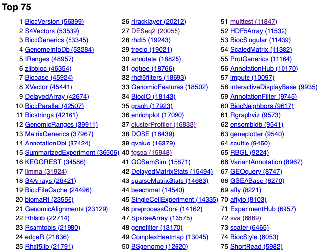

Screenshot of the most popular BioConductor packages

# R packages: How to distribute your ideas

- (In class: Looking at the folder organization of an R package)

# GitHub: How to distribute your ideas

- GitHub serves a slightly different purpose
- In a project, for yourself:
  - Version control (We will discuss this in detail later today)
- In a project, for others:
  - Stay up-to-date on what changes happens to a codebase
  - Take a quick peek to view the source code in a convenient way

# GitHub: How to distribute your ideas

- When it’s time for you to find a job:
  - Your GitHub profile is a great way to demonstrate your coding portfolio to future employers
  - Your GitHub provides a natural way to host your personal webpage

# GitHub: Examples of webpages

- https://linnykos.github.io/
- https://gqi.github.io/
- https://anna-neufeld.github.io/
- https://yezhengstat.github.io/
- https://rdevito.github.io/web/
- https://ekatsevi.github.io/
- https://zhimeir.github.io/
- https://larrylehan.github.io/
- https://frkoehle.github.io/
- https://satarupa3671.github.io/
- https://lsn235711.github.io/
- https://mcelentano.github.io/
- https://yingma0107.github.io/
- https://zji90.github.io/
- https://jichunxie.github.io/index.html

# GitHub: Examples of webpages

- To see how these websites were built, type in: https://github.com/[[github username]]/[[github username]].github.io.
- For example, https://github.com/linnykos/linnykos.github.io

# GitHub and R: The secret (and powerful) combination

- By combining GitHub and R, you can also make a website for your **project**
- This is called Pkgdown, which will cover near the end of the quarter
  - https://linnykos.github.io/tiltedCCA/
  - https://statdivlab.github.io/radEmu/
  - https://anna-neufeld.github.io/countsplit.tutorials/
  - https://katsevich-lab.github.io/sceptre/
  - https://stephenslab.github.io/fastTopics/
  - https://linnykos.github.io/561_s2025_example/. This is our demo package for this course. (Your final project is to make something like this.)

# Structure and expectations

- Weekly lectures
  - Live and recorded
- Homeworks
  - Most of your learning will happen through completing the homeworks!
  - Approximately 4 over the course of the quarter
  - Final project about using the skills you’ve learned during this course on any codebase you care about
  - Graded pass/fail
    - Pass: a good faith effort at every question that reflects a command of the concepts covered in - Lecture
  - To get credit for the class, you must pass all homeworks
- Weekly office hours

More details in Syllabus

# Going over the syllabus

- (In class: Pulling up the syllabus)
- Main things to discuss:
  - Expectations inside the classroom
  - Collaboration policy
  - Usage of ChatGPT
  - Submission of homeworks
  - Mental health

# Rest of today’s class

1. A tour of RStudio
2. A tour of https://github.com/linnykos/561_s2025_example
3. A conception of what GitHub is
4. Discussion of homework 1

# Pause

Any questions? (About the whirlwind demos or the syllabus)

# Tour of RStudio

- (In class: Showcasing RStudio)
- If you would like some reading material:
  - https://book.cds101.com/a-guided-tour-of-rstudio-servers-default-interface.html
  - http://mercury.webster.edu/aleshunas/R_learning_infrastructure/Tour%20of%20RStudio.html

# Tour of an example GitHub of an R repository

- (In class: https://github.com/linnykos/561_s2025_example)
- Observe:
  - The website associated with this demo package: https://linnykos.github.io/561_s2025_example/
  - R code: https://github.com/linnykos/561_s2025_example/tree/main/R
  - Loading in the entire package via `library(UW561S2025Example)`
  - Documentation via `?run_example`
  - Unit tests via `devtools::test()` (if I open the project in RStudio)
  - Pushing and pulling to sync changes with GitHub
  - Ability to install the package from GitHub via `devtools::install_github("linnykos/561_s2025_example")`

# A broader view: What is “version control”?

*Version control* refers to how you handle different versions of files.

A common approach to version control is changing file names:

- papersims.R

# A broader view: What is “version control”?

*Version control* refers to how you handle different versions of files.

A common approach to version control is changing file names:

- papersims.R
- papersims-v2.R
- papersims-tmp.R
- papersims-comments.R

# A broader view: What is “version control”?

*Version control* refers to how you handle different versions of files.

A common approach to version control is changing file names:

- papersims.R
- papersims-v2.R
- papersims-tmp.R
- papersims-comments.R
- papersims-asdf.R
- papersims-v5.R
- papersims-final.R

# A broader view: What is “version control”?

*Version control* refers to how you handle different versions of files.

A common approach to version control is changing file names:

- papersims.R
- papersims-v2.R
- papersims-tmp.R
- papersims-comments.R
- papersims-asdf.R
- papersims-v5.R
- papersims-final.R
- papersims-finalMondayedits.R
- papersims-final_final.R
- papersims-final_final2.R

# A broader view: What is “version control”?

1. How many versions until this becomes intractable?
2. *Date Modified* sorting does not always help
3. Tracking changes is very difficult… merging and reverting is even harder…
4. More and more files with more collaborators
5. A dreaded computer crash

Dropbox and Google Docs can help with some of these issues, but generally not (3) or (4)!

We want to have a general approach to version control that can handle many different types of files (`.R`, `.Rmd`, `.tex`, etc.)

# Git

`git` is an open-source version control system (VCS):

- Track changes to code and documents
  - *What* changes by *who* and *when*?

GitHub is a code-repository service that uses git’s VCS:

- Collaborate with others effectively
- Distribute code
- Solicit improvements (*pull* requests)
- Track issues & feature requests
- Try out new things and *revert* if they don’t work
- Remote backup of files
- Build your coding portfolio!

# Git with life

I use git and GitHub for all my work*! [Kevin’s note: I took this line from Amy, so she uses git and GitHub for everything as well]

- Collaborations
  - All my papers and R projects are on git
  - I honestly don’t know why you would sensibly not use git for any project
- Portability
  - As long as I have any computer, I can work on my latest paper/draft/lecture *anywhere*, because I back them up with git
- Keep track of your “to-do” list
  - Never forget anything again! Remind yourself what still needs doing with “Issues”

{* Except data. GitHub doesn’t like files over 500 Mb. And definitely not sensitive human genetic data.}

# Git with life

Personal story: I’ve destroyed or lost my laptop (or have had close calls) many times since high school.

- Left it in Uber
- Forgot my carry-on when deboarding my flight, and my laptop was in my carry-on
- Spilled water on my keyboard
- Got cooking oil into my laptop when I put purchased take-out food and my laptop in my backpack on the way home

Since everything was on Dropbox and GitHub, the only consequence was that I: 1) needed to spend money buying a new laptop, and 2) was angry at myself for being so careless. But I did **not** lose many months/years of my work.

# Git with life

[[Kevin’s note: These comments are mainly from Amy, but I wholeheartedly agree.]]

- Customize existing work
  - Do you like a tool package but want to rename something? You can `fork` it
- Visibility: social/professional network
  - Recruiters will likely look at yours
  - I always look at job candidates’ GitHub pages to see if they are serious about developing good software
- Necessity
  - Every software company uses some form of version control (and some use systems even more complex than git)

# How does GitHub work?

“Git” is version control on your laptop. “GitHub” is putting this version control repository on the internet.

[figure not shown]

From https://www.simplilearn.com/tutorials/git-tutorial/git-push-command

# Tour of using GitHub from RStudio

For some extra reading material

- https://rfortherestofus.com/2021/02/how-to-use-git-github-with-r

# How does GitHub and R packages work?

- For now, you can use git and GitHub within RStudio
- Later in the quarter, I will show you how I (and most people) use git and Github, which is through the Terminal
- I will also tell you how R packages work (bit by bit) over the quarter

# With the remaining time…

- (In class: Get everyone set up on GitHub, to start Question 1 of Homework 1)
- Please see https://gist.github.com/Z3tt/3dab3535007acf108391649766409421 for additional information on how to set up your R Studio
- Next week: Reviewing the basics (and some more fancy things) in `R` by default
  - data frames
  - `apply` family
  - indexing elements
  - `factor` variables
  - and more!